# Stat 385 Homework 1

Teng Li

6/24/2017

## Exercise 0: Know Thine Environment

```r
yn = readline(prompt="Hello, what is your name? ")
```

```
## Hello, what is your name?
```

```r
cat("Hello ", yn,"! I am Teng Li.", sep = "")
```

```
## Hello ! I am Teng Li.
```

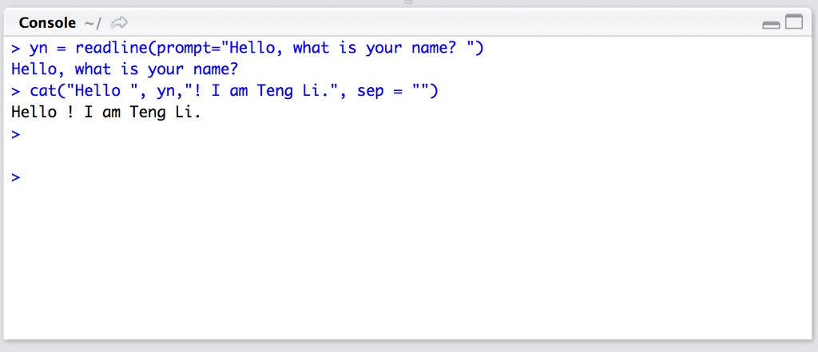

Online R-studio

## Exercise 1: Where am I?

1. The instructor for this class is James Balamuta.
2. The office is 122 Illin Hall. The office hours are Monday and Tuesday from 12:00 PM - 1:00 PM CDT.
3. The right way is: [STAT 385] Specific group project question. And this must be sent from an @illinois.edu account.
4. The time for the class is 3:00 PM - 4:50 PM, on Monday, Tuesday and Thursday. The location is Sieble 1105.
5. There are 2 exams. The mid-term exam is on July 6th. And the final exam is on August 3rd.
6. There are four phases: Proposal, Progress Update, Project Presentation, Final Project Report. Each phase is worth 43.75 points. The student’s grade is based on the contribution and individual peer evaluations.

## Exercise 2: To github and Beyond

1. Github profile : https://github.com/Teng-Li3
2. Repository: https://github.com/Teng-Li3/helloworld3

## Exercise 4:

3. Absolute path: /master/helloworld3/HW1/analysis. Relative path: ./analysis.
- If we only use $RANDOM, we have 26926, 8097, and 31950. Using $((1+ RANDOM % 10)), we have the number 4, which is in the range of 1-10.
- Both command will generate random numbers.
- 5. First 5 numbers: 10,3,8,4,5. Last 5 numbers: 6,2,5,5,7. They are all in the range 1-10. However, they are different random numbers.
- - Section 1:Define variables for later loop.
  - Section 2: A while loop that calculate the summation of all the numbers in a line (sum) and how many numbers we have (count).
  - Section 3: If statement: if the procudure is right, then calculate the mean of these numbers. (mu=sum/count) If the procedure is not right, say :Please supply a file with more than 1 line of numerical input.
  - Mean of continuous uniform distribution is
    $$(\frac{a+b}{2})$$
    , where a,b are the minimum and maximum limits of the sample. The results is fixed. However, in our case, if we have different numbers (count), we might have different results.
  - Use cd/../ to change to my home directory.

## Exercise 5 part(1)

```r
a = rep(0,25)                        # Define a

b1 = seq(1,25,by=1 )
b =  b1^2                            # Define b

d=seq(0,1,length.out=25)             # Define d

e1=seq(1,25)
e=log(e1)                            # Define e

set.seed(25)
y  = 2 * a + b / 4 + 8 * d - 3 * e + rnorm(25, 0 , 1)          # Define y
```

## Exercise 5 part(2) : define y with seed.

```r
a = rep(42,25)                       # Define a

b1 = seq(1,25,by=1 )
b =  b1^2                            # Define b

d=seq(0,1,length.out=25)             # Define d

e1=seq(1,25)
e=log(e1)                            # Define e

set.seed(25)                         # With seed
y  = 2 * a + b / 4 + 8 * d - 3 * e + rnorm(25, 0 , 1)                # Define y
```

## Exercise 5 part(3): define y without seed.

```r
a = rep(42,25)                       # Define a

b1 = seq(1,25,by=1 )
b =  b1^2                            # Define b

d=seq(0,1,length.out=25)             # Define d

e1=seq(1,25)
e=log(e1)                            # Define e

y  = 2 * a + b / 4 + 8 * d - 3 * e + rnorm(25, 0 , 1)                # Define y
```

The difference:

1. [1] 84.03817 82.21230 82.46752 85.16265 85.25489 88.84585 94.14631 96.60630 [9] 100.42464 105.03435 108.64686 114.88699 122.00722 127.95978 136.87520 145.60981 [17] 152.36692 162.95795 172.96257 180.33637 192.34051 202.89565 214.33211 228.50027 [25] 237.00773
2. [1] 83.14647 84.15668 83.68915 83.69165 85.85374 88.09293 91.90211 96.40126 [9] 100.25712 105.46445 111.53414 114.77233 121.80974 128.33190 135.88071 144.93671 [17] 153.13824 162.86495 170.92086 182.13512 191.73482 203.01131 211.83194 226.48465 [25] 237.85666
3. All the numbers are different. However, the differences are very small.

## Exercise 5 part(4)

```r
f =letters

g= c(f,b)
```

Numbers in b are now in “”. For example, we have “1”.

## Exercise 5 part (5)

```r
m = y>10                       # Create logical vetor

sum(y>10)                      # Number of elements greater than 10
```

```
## [1] 25
```

## Exercise 6

```r
# Problem 1
for (n in 1:100)
{
  cat( (-1)^(2*n+1))
}
```

```
## -1-1-1-1-1-1-1-1-1-1-1-1-1-1-1-1-1-1-1-1-1-1-1-1-1-1-1-1-1-1-1-1-1-1-1-1-1-1-1-1-1-1-1-1-1-1-1-1-1-1-1-1-1-1-1-1-1-1-1-1-1-1-1-1-1-1-1-1-1-1-1-1-1-1-1-1-1-1-1-1-1-1-1-1-1-1-1-1-1-1-1-1-1-1-1-1-1-1-1-1
```

```r
# Problem 2
for (n in 1:100)
{
  cat( (-1)^(2*n))
}
```

```
## 1111111111111111111111111111111111111111111111111111111111111111111111111111111111111111111111111111
```

```r
i=0
for (n in 2:100)
{
  new_num=cos(n*pi) /(sqrt(n))
  i=i+new_num
}
cat(new_num)
```

```
## 0.1
```

```r
i=0
for (n in 2:100)
{
  new_num=((-1)^(n+1))/(n)
  i=i+new_num
}
cat(new_num)
```

```
## -0.01
```

```r
i=0
for (n in 1:100)
{
  new_num=(((-1)^(2*n))*n)/(2*n+5)
  i=i+new_num
}
cat(new_num)
```

```
## 0.4878049
```

## Exercise 7

```r
for (i in 1:100)
{
  if (i %% 3 == 0 || i %% 5 == 0){
    cat('FizzBuzz')
  }

  else if (i %% 3 == 0 ) {
    cat('Fizz')
  }

  else if (i %% 5 == 0 ) {
    cat('Buzz')
  }

  else {
    cat(i)
  }

}
```

[output not shown]